# Machine Learning Week 3

Nikolai Klassen

19 Oktober 2017

# Trees, random Forests, Bogging…

If data is splitble into various homogenous groups, the data is very easy to interpretate and causal interference are made easier than in complex data frames.

This data is non-linear: they suse interaction between different variables. Using data trees makes transformation less importnant.

Example: Obama Clinton Divide. Homogenous groups are taken into account and their support realtive to the other homogenous groups.

How to basic algorithm:

1. Start with all variables
2. Find the variable that best separets the outcome.
3. Divide the data into two groups: “leaves” on the node.
4. Within each split, find the best variable that separets the outcome
5. Continue until the groups are too small or sufficiently “pure”

Measures of impurity:

p is the probability for the cases in which either m or ca happen.

1. Misclassification Error:

$p_{m,k} = \frac{1}{N_{m}} \sum_{in Leaf m} 1(y_i = k)$

with 0 = perfect purity and 0.5 = no purity.

2. Gini Index - not to be confused with the Gini Coefficient:

1 - the squared probabilties that one case belongs to one of the other classes.

3. Deviance/Information Gain:

$-\sum_{k=1}^K p_{mk}log_2 p_{mk}$

- the sum of the probability of being assigend to case m in leaf k.

0 = perfect purity in the leaf, 1 = no purity in the leaf

### Programming a Model

Function Calls are party, rpart, and tree.

### Ploting a Tree

1. Making a model with train(method =“rpart”) and ploting it with plot. -> model$finalmodel
2. fancyRpartPlot() is fancier.

# Bootstrap aggregating aka. bagging

The basic Idea in this approach is to resample cases and recalculate predictions in order to get an average or majority vote. It generates a similar bias with reduced variance.

Example in the ozone-data.

```r
library("ElemStatLearn")
data("ozone")
ozone <- ozone[order(ozone$ozone),]
head(ozone)
```

```
##     ozone radiation temperature wind
## 17      1         8          59  9.7
## 19      4        25          61  9.7
## 14      6        78          57 18.4
## 45      7        48          80 14.3
## 106     7        49          69 10.3
## 7       8        19          61 20.1
```

### Bagged loess

Were going to try to predict temperature by ozone. The Basic Idea is to create a matrix and loop over the data with sampled data from the ozone dataset.

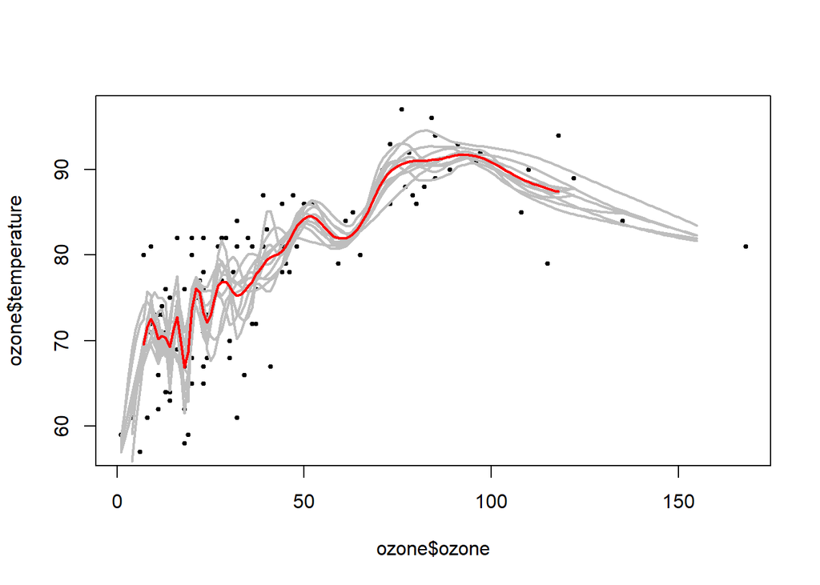

```r
ll <- matrix(NA, nrow = 10, ncol = 155) ## loop matrix

for(i in 1:10){
  ss <- sample(1:dim(ozone)[1], replace = T)
  ozone0 <- ozone[ss,]; ozone0 <- ozone0[order(ozone0$ozone),]
  loess0 <- loess(temperature~ ozone, data= ozone0, span= 0.2)
  ll[i,] <- predict(loess0, newdata = data.frame(ozone=1:155))
}

## this makes 10 different samples and makes 10 different models averaging the effect.

plot(ozone$ozone, ozone$temperature, pch =19, cex = 0.5)

for(i in 1:10){lines(1:155, ll[i,], col = "grey", lwd =2)}

lines(1:155, apply(ll, 2, mean), col = "red", lwd= 2)
```